# Cleaning WVS Data

Leigh Allison

March 8, 2017

First we need to tell R where are the data files are stored.

```r
setwd("C:/Users/laall/Desktop/GitHub/WVS_Analysis_Leigh_Allison")
```

# Importing Data

I have subsetted the data from the Wave 6 WVS based on the integrated code book. In total there are 348 variables/questions. A couple of questions have two variables associated with them which will be explained later.

```r
PFL_data      <- read.csv("PFL_Raw_Data.csv")
Enviro_data   <- read.csv("Enviro_Raw_Data.csv")
Work_data     <- read.csv("Work_Raw_Data.csv")
Fam_data      <- read.csv("Fam_Raw_Data.csv")
PS_data       <- read.csv("PS_Raw_Data.csv")
RM_data       <- read.csv("RM_Raw_Data.csv")
Nation_data   <- read.csv("Nation_Raw_Data.csv")
Security_data <- read.csv("Security_Raw_Data.csv")
Science_data  <- read.csv("Science_Raw_Data.csv")
SD_data       <- read.csv("SD_Raw_Data.csv")

# We need the names in order to merge it with a world map. In order for the merge to work, we had to change the names to match the world map shape file.
Country_Names <-read.csv("Country_Code_Names.csv")
Country_Names <-Country_Names[,c("Country.Code", "Country.Title")]
```

Right now, each row in the data file represents an indvidual response. In order to show national trends, each response needs to be condensed (aggregated) into one national metric. There are several different ways you can aggregate the data and several considerations about the data.

First, the metric used depends on the type of question - categorical or ordinal. For categorical questions, the national statistic can be a mode or median (if the data is also ordinal). For questions with a likert scale (oridnal/numerical questions), a national average is possible; however, the likert scale is interpreted differently be each respondant, creating a national average or mean that is not as meaningful. The WVS does not include any traditional numerical responses. However, all responses can be counted and sorted by the response/answer chosen by each individual respondant. Counts can be compared across different questions and nations because they are unit of measure is the same - an single response by a respondant.

Second, there are slight variations to the WVS depending on the country. For example Iquestion 125 asks about political organizations, specific to each country. Each nation will have different response categories. Futhermore some questions were simpily not asked or were contionial on a repsondants previous questions response (Questions V90-V94). These questions were removed from this analysis, so that the number of reponses were approximately equal.

Third, the goal of this analysis is to create principle components representing cultural values; therefore, the aggregation method used must allow for nations to be compared within a questions but also for questions to be compared and combined to understand national trends. Calculating a mean or median for each nationa allows for comparisons of different nations responses within single questions; but it does not allow us to combine questions into cultural values. Counts of responses are compariable across questions and nations as the unit of measurement is the same; however, it greatly increases the number of variables in the analysis. For each question, each response would have to be represented by a single variable - creating thousands of variables to analyze with only 60 countries in the sample. One way to reduce the number of variables would be to only use the variables representing the most popular (mode or median) response for each question. HOwever, large amounts of data are lost in this process.

Finally, it is also important to consider tha these variables are going to be used in a principle component analysis and should therefore be on similar scale. One way to do this is to make the a national precentage of individuals that answered each variable by taking the count of response and dividing by the total number of people who answered the question.

In order to understand the best course for analysis, we will first break the questions into categorical and ordinal data sets.

```r
PFL_Categorical_Data <- read.csv("PFL_Categorical_subset.csv")
Enviro_Categorical_Data <- read.csv("Enviro_Categorical_subset.csv")
Work_Categorical_Data <- read.csv("Work_Categorical_subset.csv")
Fam_Categorical_Data <- read.csv("Fam_Categorical_subset.csv")
PS_Categorical_Data <- read.csv("PS_Categorical_subset.csv")
RM_Categorical_Data <- read.csv("RM_Categorical_subset.csv")
Nation_Categorical_Data <- read.csv("Nation_Categorical_subset.csv")
Security_Categorical_Data <- read.csv("Security_Categorical_subset.csv")
#Science doesn't have categorical questions
SD_Categorical_Data <- read.csv("SD_Categorical_subset.csv")

Categorical_DF_List <- list(PFL_Categorical_Data,
                            Enviro_Categorical_Data,
                            Work_Categorical_Data,
                            Fam_Categorical_Data,
                            PS_Categorical_Data,
                            RM_Categorical_Data,
                            Nation_Categorical_Data,
                            Security_Categorical_Data)
```

```r
PFL_Ordinal_Data <- read.csv("PFL_Ordinal_subset.csv")
#Environmental questions are all categorical
Work_Ordinal_Data <- read.csv("Work_Ordinal_subset.csv")
#Family questions are all categorical
PS_Ordinal_Data <- read.csv("PS_Ordinal_subset.csv")
RM_Ordinal_Data <- read.csv("RM_Ordinal_subset.csv")
#Nation questions are all categorical
#Security questions are all categorical
Science_Ordinal_Data <- read.csv("Science_Ordinal_subset.csv")
#Socio-Demographic(SD) not included - V231, 232, 233 - in cultural dimensions may be a moderator
SD_Ordinal_Data <- read.csv("SD_Ordinal_subset.csv")

Ordinal_DF_List <- list(PFL_Ordinal_Data,
                        Work_Ordinal_Data,
                        PS_Ordinal_Data,
                        RM_Ordinal_Data,
                        Science_Ordinal_Data)
```

# Questions for Cleaning

In each list of questions and response the country code and weight are included. This steps removes the duplicate country code and weight columns from the questions being combined into one matrix.

```r
#install.packages("dplyr")
library("dplyr")
#need to remove duplicate columns (country names and weight columns)
Categorical_subset <- as.data.frame(list(Categorical_DF_List) %>%
    Reduce(function(dtf1,dtf2) left_join(dtf1,dtf2,by="V2"), .))
Categorical_subset <-  subset(Categorical_subset, select=-c(V2.1,V2.2,V2.3,V2.4,V2.5,V2.6,V2.7,                                                            X.1,X.2,X.3,X.4,X.5,X.6,X.7,
                             V258.1, V258.2,V258.3,V258.4, V258.5,V258.6,V258.7))

Ordinal_subset  <- as.data.frame(list(Ordinal_DF_List) %>%
    Reduce(function(dtf1,dtf2) left_join(dtf1,dtf2,by="V2"), .))
Ordinal_subset <- subset(Ordinal_subset, select=-c(V2.1,V2.2,V2.3,V2.4,
                                                    X.1,X.2,X.3,X.4,
                                                    V258.1, V258.2,V258.3, V258.4))
```

# Cleaning Data

When downloaded from the WVS wesite, this data was coded with numbers to represent the response chosen or why a response is missing. For example, -5 means missing or inapporiate response, while -4 respresents not asked in that survey. In this next section of code, we converted -5 (inapplicable/refused/missing), -4 (not asked in survey), and -3 (not applicable), to -6 so that they are not included in the calculation. These (-6) responses represent an administractive decision; whereas -2 is when the respondant is asked the question and chooses not to answer and -1 is when the respondant answers that they do not know.

While the differences in these administratively missing responses have the potential to show interesting trends related to why a questions was or was not answered; the objective of this research is to determine how the reponses can be combined to determine cultural values, not how the survey setup are affecting the questions. Therefore, -2 as “no response” and -1 is “Don’t know” and were left in the survey responses.

```r
# Install and load the car package which contains the code that recodes cells and returns an updated dataframe
install.packages("car", repos = 'http://cran.us.r-project.org')
library(car)
```

```r
Recodetoneg6<- function(QuestionColName){
  QuestionColName<- recode(QuestionColName, "c(-5, -4, -3)= -6")
}

Updated_Categorical_data <- as.data.frame(apply(Categorical_subset,2,Recodetoneg6))
Updated_Ordinal_data <- as.data.frame(apply(Ordinal_subset,2,Recodetoneg6))

write.csv(Updated_Categorical_data, "Updated_Categorical_Data.csv")
write.csv(Updated_Ordinal_data, "Updated_Ordinal_Data.csv")
```

We now have two data matrices - one with categorical questions and one with ordinal questions. The rows are individual responses and the columns are questions with the exception of the first two columns which contain the country code and weight.

# Calculations for Categorical Questions - Counting

Now the precentage of people who answered each category for each questions can be computed by nation. In this first function we are counting the number of weighted responses to each questions response. The function returns a dataframe with the number of responses for each category as a column and nations as rows. Note, the function must be used in combination with the aggregate function in order to have the rows to be nations. We show an example in question calculation before applying it to all of the WVS questions.

```r
Count_Calc <- function(aColumn){
  miss=0
  r0=0
  r1=0
  r2=0
  r3=0
  r4=0
  r5=0
  r6=0
  r7=0
  r8=0
  rneg1=0
  rneg2=0
  rneg6=0

  count =1

  for (value in aColumn){
    if(is.na(value)){
      miss = miss + 1
      next
    }
    if(value == 0){
      r0 = r0 + Updated_Categorical_data$V258[count]
      next
    }

    if(value == 1){
      r1 = r1 + Updated_Categorical_data$V258[count]
      next
    }
    if(value == 2){
      r2 = r2 + Updated_Categorical_data$V258[count]
      next
    }
    if(value == 3){
      r3 = r3 + Updated_Categorical_data$V258[count]
      next
    }
    if(value == 4){
      r4 = r4 + Updated_Categorical_data$V258[count]
      next
    }
    if(value == 5){
      r5 = r5 + Updated_Categorical_data$V258[count]
      next
    }
    if(value == 6){
      r6 = r6 + Updated_Categorical_data$V258[count]
      next
    }
    if(value == 7){
      r7= r7 + Updated_Categorical_data$V258[count]
      next
    }
    if(value == 8){
      r8 = r8 + Updated_Categorical_data$V258[count]
      next
    }
    if(value == -1){
      rneg1 = rneg1 + Updated_Categorical_data$V258[count]
      next
    }
    if(value == -2){
      rneg2 = rneg2 + Updated_Categorical_data$V258[count]
      next
    }
    if(value == -6){
      rneg6 = rneg6 + Updated_Categorical_data$V258[count]
      next
    }
    count = count + 1
  }
#NOTE: the majority questions do not have 9 categories.
  #rneg1 represents I don't know
  #rneg2 is a true none response or missing value
  #rneg6 is not applicable or not asked - so it was an administrative decision to not keep the question

  sumbyresponse <-rbind(r0, r1, r2, r3, r4, r5, r6, r7, r8, rneg1, rneg2, rneg6)
return(sumbyresponse)
}
```

# Example Categorical Question Calculation

Before we run the analysis on all the questions, let’s look at the break down of question V60. There are only 4 categorical responses, so the 5th category should have zero responses.

```r
#The result shows the number of people (worldwide who answered category 1, 2, 3, 4)
V60_Global <- Count_Calc(Updated_Categorical_data$V60)

#The result calculates the number of people who answered category 1, 2, 3, 4 by country
V60_Country_Breakdown <- aggregate(Updated_Categorical_data$V60,
          by=list(Updated_Categorical_data$V2),
          Count_Calc, simplify=FALSE)

#Need to reformat the above output of the aggregate function - used loop below
Question_Counts_Example <- data.frame()
for( i in 1:60){
 Count <- t(as.data.frame(V60_Country_Breakdown$x[i]))
 Question_Counts_Example  <- as.data.frame(rbind(Question_Counts_Example, Count))
}
row.names(Question_Counts_Example ) <- as.character(V60_Country_Breakdown$Group.1)

#To calculate th precentage of people who answered each category by country. We start by summing the rows and then divide each count by the sum.
country_sums <- as.data.frame(apply(Question_Counts_Example , 1, sum))
V60_Precent <-Question_Counts_Example [1,]/country_sums$`apply(Question_Counts_Example, 1, sum)`[1]
#V60_Precent
```

# Categorical Precentage Calculation

To apply this function to the all the questions, we must use a “for” loop. The Count_Calc function is designed to count the responses to an individual question. The “for” loops allows the function to be applied to each column. As with the example the Count_Calc function will create dataframe for each function counting the number of respondants who selected which response and then the precentages (ranging for 0 to 100) with the nation are calculated. A table containing the reponse choice precentages by nation will be created and saved for each nation. The next step is to combine all of those dataframes into one dataframe with all the variables as columns and nations as rows.

```r
#Create list of questions to loop function over
Cat_Question_Column_Names=names(Updated_Categorical_data)[c(4:228)] #
#Create an empty list to name the count dataframes
Cat_Question_Column_Names_Count <- c()

#Create a new variables to hold the count calculations
for(i in 1:length(Cat_Question_Column_Names)){
  Question_Name <- paste(Cat_Question_Column_Names[i], "Count", sep = "_")
  Cat_Question_Column_Names_Count <- c(Cat_Question_Column_Names_Count, Question_Name)
  }

PS_Percent_Cat_data <-data.frame()
count = 1

#Apply the Count_Calc function to all the categorical questions.
for(col in Cat_Question_Column_Names){ #starting with first question
    #sumbyresponse_all dataframe contains the the categories as columns
    #and the weighted sums for the number of people who answered in that category.
    sumbyresponse_all <- aggregate(Updated_Categorical_data[,col],
          by=list(Updated_Categorical_data$V2),
          Count_Calc, simplify=FALSE)

   #Reformat the sumbyresponse_all dataframe into countries as rows & columns as categories
   Question_Counts <-data.frame()
   for(i in 1:60){
      Count <- t(as.data.frame(sumbyresponse_all$x[i]))
      Question_Counts <- as.data.frame(rbind(Question_Counts, Count))
   }
   row.names(Question_Counts) <- as.character(sumbyresponse_all$Group.1)

   #To store the count dataframe under question name
   assign(Cat_Question_Column_Names_Count[count], Question_Counts)

   #Add up rows to determine total number of people from each country who answered each question
   country_sums <- as.data.frame(apply(Question_Counts, 1, sum))
   precentages <-data.frame() #this dataframe will store the precentage of people who answered each category

   for(i in 1:60){
     percent <- round(Question_Counts[i,]/country_sums$`apply(Question_Counts, 1, sum)`[i]*100,3)
     precentages <- rbind(precentages, percent)
   }

    colnames(precentages) <- c("0", "1_Ref", "2", "3", "4", "5", "6", "7", "8", "Neg1", "Missing", "AdminNA")
    Categorical_Percentages<- precentages

  #Need to store the precent dataframe under question name
   colnames(Categorical_Percentages) <- paste(Cat_Question_Column_Names[count], colnames(Categorical_Percentages), sep = "_")
   assign(Cat_Question_Column_Names[count], Categorical_Percentages)
   count = count+1
} #ending analysis of one question looping back to start another question
```

# Full Categorical Data

We now will combine all the dataframes into one matirx. This data frame contains a column for each categorical response of each question for all questions in the Wave 6 of the WVS. The columns are first named with the question number and then by the coded category. Not all the questions have equal number of categories which is why some questionshave columns with all zeros.

```r
Cat_Precentage_DFs_list<- list(V4=V4, V5=V5, V6=V6, V7=V7, V8=V8, V9=V9, V10=V10,
                               V11=V11, V12=V12, V13=V13, V14=V14, V15=V15, V16=V16,
                               V17=V17, V18=V18, V19=V19, V20=V20, V21=V21, V22=V22,
                               V25=V25, V26=V26, V27=V27, V28=V28, V29=V29, V30=V30,
                               V31=V31, V32=V32, V33=V33, V34=V34, V35=V35, V37=V37,
                               V42=V42, V39=V39, V38=V38, V36=V36, V40=V40, V41=V41,
                               V43=V43, V44=V44, V24=V24, V70=V70, V71=V71, V72=V72,
                               V73=V73, V75=V75, V76=V76, V77=V77, V78=V78, V79=V79,
                               V74=V74, V165=V165, V166=V166, V167=V167,
                               V168=V168, V169=V169,
                               V81=V81, V82=V82, V83=V83,V45=V45,V46=V46,
                               V102=V102, V49=V49, V54=V54, V51=V51, V52=V52, V50=V50, V48=V48, V47=V47, V53=V53,
                               V60=V60, V61=V61, V62=V62, V63=V63, V64=V64, V65=V65,V66=V66, V67=V67, V68=V68, V69=V69,
                               V80=V80, V84=V84, V85=V85, V86=V86, V87=V87, V88=V88, V89=V89,
                               V108=V108, V109=V109, V110=V110, V111=V111, V112=V112, V113=V113, V114=V114, V115=V115,
                               V116=V116, V117=V117, V118=V118, V119=V119,
                               V120=V120, V121=V121, V122=V122, V123=V123, V124=V124,V126=V126,
                               V127=V127, V128=V128, V129=V129, V130=V130, V142=V142,
                               V217=V217, V218=V218, V219=V219, V220=V220, V221=V221,
                               V222=V222, V223=V223, V224= V224,V225=V225, V226=V226, V227=V227,
                               V143=V143, V145=V145, V146=V146, V147=V147, V148=V148, V149=V149, V150=V150, V151=V151,
                               V153=V153, V154=V154, V155=V155, V156=V156,
                               V211=V211,
                               V103=V103, V104=V104, V105=V105, V106=V106, V107=V107,
                               V212=V212, V213=V213, V214=V214, V216=V216, V243=V243, V244=V244, V245=V245, V246=V246,
                               V170=V170, V171=V171, V172=V172, V173=V173, V174=V174, V175=V175, V176=V176, V177=V177,
                               V178=V178, V179=V179, v180=V180, V181=V181, V182=V182, v183=V183, V184=V184, V185=V185,
                               V186=V186, V187=V187, V188=V188, V189=V189, V190=V190, V191=V191,
                               V74B=V74B, V90=V90, V91=V91, V92=V92, V93=V93, V94=V94,
                               V160A=V160A, V160B=V160B, V160C=V160C, V160D=V160D, V160E=V160E, V160F=V160F,
                               V160G=V160G, V160H=V160H, V160I=V160I, V160J=V160J,
                               V217_ESMA=V217_ESMA, V218_ESMA=V218_ESMA, V224_ESMA=V224_ESMA,
                               V220_ESMA=V220_ESMA, V221_ESMA=V221_ESMA,
                               V222_ESMA=V222_ESMA,
                               V228A=V228A, V228B=V228B, V228C=V228C,V228D=V228D,
                               V228E=V228E, V228F=V228F, V228G=V228G, V228H=V228H, V228I=V228I, V228J=V228J, V228K=V228K,
                               V243_AU=V243_AU, V244_AU=V244_AU)

#Questions 144 (religion), 215 (political organizations - 18 variables), 247 (language) were removed beause they had to many categories.
#219_ESMA was removed because it was not answered by any of the 60 countries.
#228 and 228_2 were removed because they are related to political parties in specific countries
country.codes <- sumbyresponse_all$Group.1
```

Contained within this dataframe are the variables representing the precentage of people from each nation who did not respond to a questions as well as those who were not asked the questions. We want to remove countries and questions that have large amounts of administrative missingness. No repsonse is considered a choice be the respondant and could introduce interesting patterns. Therefore, the true missingness or no response catgory is kept in the analysis. We still created a separate dataframe inorder to visualize the missingness of both kinds.

# Missing Data

```r
#Making a dataframe of columns for the missing responses -
Missing_DF <- c()
for(df in Cat_Precentage_DFs_list){
  Missing_DF_add <- df[,11]
  Missing_DF <- cbind(Missing_DF, Missing_DF_add)
}
Cat_Question_Column_Names_Missing <- names(Cat_Precentage_DFs_list)
colnames(Missing_DF) <- Cat_Question_Column_Names_Missing
rownames(Missing_DF) <- country.codes

#Created a weighted scatterplot to determine which questions or countries should be removed.
library(corrplot)
#install.packages("RColorBrewer")
library(RColorBrewer)

#Missing_DF1 <- Missing_DF[1:60,1:72]
#pdf("Missing_DF1_Plot.pdf", width = 28, height = 14, paper="USr")
#corrplot(Missing_DF1, is.corr = FALSE, method = "color", tl.cex=0.5, tl.col= "black" , col= colorRampPalette(c("blue", "gray", "red"))(100), cl.lim=c(0,100), addgrid.col = "white", title = "Missingness 1 of 3", mar = c(2,2,2,2))
#dev.off()

#Missing_DF2 <- Missing_DF[1:60,73:144]
#pdf("Missing_DF2_Plot.pdf", width = 28, height = 14, paper="USr")
#corrplot(Missing_DF2, is.corr = FALSE, method = "color", tl.cex=0.4, tl.col= "black" , col= colorRampPalette(c("blue", "gray", "red"))(100), cl.lim=c(0,100), addgrid.col = "white", title = "Missingness 2 of 3", mar = c(2,2,2,2))
#dev.off()

#Missing_DF3 <- Missing_DF[1:60,144:202]
#pdf("Missing_DF3_Plot.pdf", width = 28, height = 14, paper="USr")
#corrplot(Missing_DF3, is.corr = FALSE, method = "color", tl.cex=0.4, tl.col= "black" , col= colorRampPalette(c("blue", "gray", "red"))(100), cl.lim=c(0,100), addgrid.col = "white", title = "Missingness 3 of 3", mar = c(2,2,2,2))
#dev.off()

#pdf("Missing_DF_Plot.pdf", width = 3000, height = 500, paper="USr")
#corrplot(Missing_DF, is.corr = FALSE, method = "color", tl.cex=0.5, tl.col= "black" , col= colorRampPalette(c("blue", "gray", "red"))(100), cl.lim=c(0,100), addgrid.col = "white", title = "Missingness", mar = c(2,2,2,2))
#dev.off()
```

# AdminNA Data

```r
#Making a dataframe of columns for the Administravitive missing (AdminNA or -6) responses -
AdminNA_DF <- c()
for(df in Cat_Precentage_DFs_list){
  AdminNA_DF_add <- as.numeric(df[,12])
  AdminNA_DF <- cbind(AdminNA_DF, AdminNA_DF_add)
}

AdminNA_DF<- as.matrix(AdminNA_DF)
Cat_Question_Column_Names_AdminNA <- names(Cat_Precentage_DFs_list)
colnames(AdminNA_DF) <- Cat_Question_Column_Names_AdminNA
rownames(AdminNA_DF) <- country.codes

summary(apply(AdminNA_DF, 2, function(x) any(is.na(x))))
```

```
##    Mode   FALSE
## logical     203
```

```r
any(is.na(AdminNA_DF) | is.infinite(AdminNA_DF))
```

```
## [1] FALSE
```

```r
#AdminNA_DF1 <- AdminNA_DF[1:60,1:72]
#pdf("AdminNA_DF1_Plot.pdf", width = 28, height = 14, paper="USr")
#corrplot(AdminNA_DF1, is.corr = FALSE, method = "color", tl.cex=0.5, tl.col= "black" , col= colorRampPalette(c("blue", "gray", "red"))(100), cl.lim=c(0,100), addgrid.col = "white", title = "AdminNA - 1 of 3", mar = c(2,2,2,2))
#dev.off()

#AdminNA_DF2 <- AdminNA_DF[1:60,73:144]
#pdf("AdminNA_DF2_Plot.pdf", width = 28, height = 14, paper="USr")
#corrplot(AdminNA_DF2, is.corr = FALSE, method = "color", tl.cex=0.4, tl.col= "black" , col= colorRampPalette(c("blue", "gray", "red"))(100), cl.lim=c(0,100), addgrid.col = "white", title = "AdminNA - 2 of 3", mar = c(2,2,2,2))
#dev.off()

#AdminNA_DF3 <- AdminNA_DF[1:60,144:202]
#pdf("AdminNA_DF3_Plot.pdf", width = 28, height = 14, paper="USr")
#corrplot(AdminNA_DF3, is.corr = FALSE, method = "color", tl.cex=0.4, tl.col= "black" , col= colorRampPalette(c("blue", "gray", "red"))(100), cl.lim=c(0,100), addgrid.col = "white", title = "AdminNA - 3 of 3", mar = c(2,2,2,2))
#dev.off()

#pdf("AdminNA_DF_Plot.pdf", width = 3000, height = 500, paper="USr")
#corrplot(AdminNA_DF, is.corr = FALSE, method = "color", tl.cex=0.5, tl.col= "black" , col= colorRampPalette(c("blue", "gray", "red"))(100), cl.lim=c(0,100), addgrid.col = "white", title = "AdminNA", mar = c(2,2,2,2))
#dev.off()
```

# Don’t Know Data

```r
#Making a dataframe of columns for the missing responses -
Dontknow_DF <- c()
for(df in Cat_Precentage_DFs_list){
  Dontknow_DF_add <- df[,10]
  Dontknow_DF <- cbind(Dontknow_DF, Dontknow_DF_add)
}
Cat_Question_Column_Names_Dontknow <- names(Cat_Precentage_DFs_list)
colnames(Dontknow_DF) <- Cat_Question_Column_Names_Dontknow
rownames(Dontknow_DF) <- country.codes


#Dontknow_DF1 <- Dontknow_DF[1:60,1:72]
#pdf("Dontknow_DF1_Plot.pdf", width = 28, height = 14, paper="USr")
#corrplot(Dontknow_DF1, is.corr = FALSE, method = "color", tl.cex=0.5, tl.col= "black" , col= colorRampPalette(c("blue", #"gray", "red"))(100), cl.lim=c(0,100), addgrid.col = "white", title = "Dontknow 1 of 3", mar = c(2,2,2,2))
#dev.off()

#Dontknow_DF2 <- Dontknow_DF[1:60,73:144]
#pdf("Dontknow_DF2_Plot.pdf", width = 28, height = 14, paper="USr")
#corrplot(Dontknow_DF2, is.corr = FALSE, method = "color", tl.cex=0.4, tl.col= "black" , col= colorRampPalette(c("blue", "gray", "red"))(100), cl.lim=c(0,100), addgrid.col = "white", title = "Dontknow 2 of 3", mar = c(2,2,2,2))
#dev.off()

#Dontknow_DF3 <-Dontknow_DF[1:60,144:202]
#pdf("Dontknow_DF3_Plot.pdf", width = 28, height = 14, paper="USr")
#corrplot(Dontknow_DF3, is.corr = FALSE, method = "color", tl.cex=0.4, tl.col= "black" , col= colorRampPalette(c("blue", "gray", "red"))(100), cl.lim=c(0,100), addgrid.col = "white", title = "Dontknow 3 of 3", mar = c(2,2,2,2))
#dev.off()

#pdf("Dontknow_DF_Plot.pdf", width = 3000, height = 500, paper="USr")
#corrplot(Dontknow_DF, is.corr = FALSE, method = "color", tl.cex=0.5, tl.col= "black" , col= colorRampPalette(c("blue", "gray", "red"))(100), cl.lim=c(0,100), addgrid.col = "white", title = "Dontknow", mar = c(2,2,2,2))
#dev.off()
```

```r
#make one DF with all the single question dataframes
#Questions 144, 247,254, 256 were removed beause they were coded using religion, languages, regions and ethnicities
#219_ESMA was removed because it was not answered by any of the 60 countries.
#228 and 228_2 were removed because they are related to political parties in specific countries
#Removed sociodemographic questions "V57"  "V58"  "V229" "V230" "V234" "V235" "V236" "V237" "V238" "V240" "V248" "V250" "V253" "V254" "V255" "V256"

Cat_Precentage_DFs <- cbind(V4,V5,V6,V7,V8,V9,V10,V11,V12,V13,V14,V15,V16,V17,V18,V19,V20,V21,V22,V25,V26,V27,V28,
                           V29,V30,V31,V32,V33,V34,V35,V37,V42,V39,V38,V36,V40,V41,V43,V44,V24,V70,V71,V72,V73,V75,
                           V76, V77,V78,V79,V74,V165,V166,V167,V168,V169,V81,V82,V83,V45,V46,
                           V102,V49,V54,V51,V52,V50,V48,V47,V53,
                           V60,V61,V62,V63,V64,V65,V66,V67,V68,V69,V80,V84,V85,V86,V87,V88,V89,V108,V109,V110,V111,V112,
                           V113,V114,V115,V116,V117,V118,V119,V120,V121,V122,V123,V124,V126,V127,V128,V129,V130,V142,
                           V217,V218,V219,V220,V221,V222,V223,V224,V225,V226,V227,
                           V143,V145,V146,V147,V148,V149,V150,V151,V153,V154,V155,V156,
                           V211,V103,V104,V105,V106,V107,V212,V213,V214,V216,V243,V244,V245,V246,
                           V170,V171,V172,V173,V174,V175,V176,V177,V178,V179,
                           V180,V181,V182,V183,V184,V185,V186,V187,V188,
                           V189,V190,V191,
                           V74B, V90, V91, V92, V93, V94,
                           V160A,V160B,V160C,V160D,V160E,V160F,V160G,V160H,V160I,V160J,
                           V217_ESMA, V218_ESMA, V224_ESMA, V220_ESMA, V221_ESMA,
                           V222_ESMA, V228A, V228B, V228C,V228D,V228E,V228F, V228G, V228H, V228I,V228J,V228K,
                           V243_AU,V244_AU)

#Remove the columns that are just zeros. This step removes categories that were not used by questions.
Cat_Final_Precentage_DFs<- Cat_Precentage_DFs[,-(which(colSums(Cat_Precentage_DFs) == 0))]
write.csv(Cat_Final_Precentage_DFs, file = "Precentage_Categorical_Data.csv")

#check that rows (representation nations) add to 100% by looking at questions V4
apply(Cat_Final_Precentage_DFs[,c(1:7)], 1, sum)
```

```
##      12      31      32      36      48      51      76     112     152
## 100.000 100.001 100.000 100.000  99.999 100.001 100.000 100.001 100.000
##     156     158     170     196     218     233     268     275     276
## 100.000 100.001 100.000 100.000 100.000 100.000 100.000 100.000 100.000
##     288     344     356     368     392     398     400     410     414
## 100.000 100.000 100.000 100.001 100.000 100.000 100.000 100.000  99.999
##     417     422     434     458     484     504     528     554     566
## 100.000 100.000 100.001 100.000 100.000 100.000 100.000 100.000 100.000
##     586     604     608     616     634     642     643     646     702
##  99.999 100.000 100.001 100.002 100.000 100.001 100.000 100.000 100.001
##     705     710     716     724     752     764     780     788     792
## 100.000 100.000 100.001  99.999 100.001 100.001 100.000 100.000 100.001
##     804     818     840     858     860     887
##  99.999 100.000 100.000 100.000  99.999 100.000
```

# Calculations for Ordinal Questions

First we need to aggregate the data into weighted sums for each country. The Likert_Count_Calc function is very similar to the Count_Calc function (in fact the only difference is it hasa more categories ot count). It returns a dataframe with countries as the rows and response categories 1 to 10, -1 (“I don’t know”), -2 (No answer), and -6 (AdminNA). Recall that when downloaded from the WVS wesite, this data was coded with numbers to represent the response chosen or why a response is missing. For example, -5 means missing or inapporiate response, while -4 respresents not asked in that survey. Earlier in this process (line 121), we converted -5 (inapplicable/refused/missing), -4 (not asked in survey), and -3 (not applicable), to -6 so that they are not included in the calculation. These (-6) responses represent an administractive decision; whereas -2 is when the respondant is asked the question and chooses not to answer and -1 is when the respondant answers that they do not know.

Similar to the Count_Calc function for the categorical questions. This function needs to be used with the aggregate function to separate by country and in a loop to analyze multiple questions at a time. We will start with an example using a single question (V95), then we will use a loop to apply the function to all of the ordinal questions in our data set.

```r
Likert_Count_Calc<- function(aColumn){

  miss=0
  r1=0
  r2=0
  r3=0
  r4=0
  r5=0
  r6=0
  r7=0
  r8=0
  r9=0
  r10=0
  rneg1=0
  rneg2=0
  rneg6=0

  count = 1

for (value in aColumn){

    if(is.na(value)){
      miss = miss + Updated_Ordinal_data$V258[count]
      next
    }
    if(value == 1){
      r1 = r1 + Updated_Ordinal_data$V258[count]
      next
    }
    if(value == 2){
      r2 = r2 + Updated_Ordinal_data$V258[count]
      next
    }
    if(value == 3){
      r3 = r3 + Updated_Ordinal_data$V258[count]
      next
    }
    if(value == 4){
      r4 = r4 + Updated_Ordinal_data$V258[count]
      next
    }
    if(value == 5){
      r5 = r5 + Updated_Ordinal_data$V258[count]
      next
    }
    if(value == 6){
      r6 = r6 + Updated_Ordinal_data$V258[count]
      next
    }
    if(value == 7){
      r7 = r7 + Updated_Ordinal_data$V258[count]
      next
    }
    if(value == 8){
      r8 = r8 + Updated_Ordinal_data$V258[count]
      next
    }
    if(value == 9){
      r9 = r9 + Updated_Ordinal_data$V258[count]
      next
    }
    if(value == 10){
      r10 = r10 + Updated_Ordinal_data$V258[count]
      next
    }
    if(value == -1){
      rneg1 = rneg1 + Updated_Ordinal_data$V258[count]
      next
    }
    if(value == -2){
      rneg2 = rneg2 + Updated_Ordinal_data$V258[count]
      next
    }
    if(value == -6){
      rneg6 = rneg6 + Updated_Ordinal_data$V258[count]
      next
    }
    count = count + 1
  }
  #Note that NA responses not included in subset.
  dataofresponses_subset<-rbind(r1, r2, r3, r4, r5, r6, r7, r8, r9, r10, rneg1, rneg2, rneg6)

  #each column is a response sum, each row is coutry
  return(dataofresponses_subset)
}
```

# Example Question Calculation

Before we run the analysis on all the questions, let’s look at the break down of question V95. It is a ordinal questions with a likert scale of 1 to 10.

```r
Ordinal_Question_Counts_Example <- data.frame()
#The result below shows the number of people (worldwide who answered category 1, 2,...,10) - not divided by country
V95_Global <- Likert_Count_Calc(Updated_Ordinal_data$V95)

#Using the aggregate function, the number of responses per country is calculated.
V95_Country_Breakdown<- aggregate(Updated_Ordinal_data$V95,
          by=list(Updated_Ordinal_data$V2),
          Likert_Count_Calc, simplify=FALSE)

#The result of aggregate function has to be reformatted into a dataframe that we will use later.
for( i in 1:60){
 Count <- t(as.data.frame(V95_Country_Breakdown$x[i]))
 Ordinal_Question_Counts_Example  <- as.data.frame(rbind(Ordinal_Question_Counts_Example, Count))
}
row.names(Ordinal_Question_Counts_Example) <- as.character(V95_Country_Breakdown$Group.1)
#To calculate a precentage, we divide the number of responses in each category by the total number of people who answered the question from that country. The first step is to calculate the country sums.
country_sums <- as.data.frame(apply(Ordinal_Question_Counts_Example, 1, sum))
#then we calculate the precentages. These precentages are for each individual response option.
V95_Precent <- Ordinal_Question_Counts_Example[1,]/country_sums$`apply(Ordinal_Question_Counts_Example, 1, sum)`[1]
#V95_Precent
#Check to make sure they add to 1.
#sum(V95_Precent[1,])
```

# Ordinal Question Count Calcuations

To determine the precentage of people who answered each response on the likert scales, we have to apply the Liket_Count_Calc function using the aggregate function within a loop. The loop will create a dataframe for each question. THe dataframe will have the countries as rows and the questions responses as columns. In each cell are the precentage of people who answered each response.

```r
Ordinal_Question_Column_Names = names(Updated_Ordinal_data)[c(4:52)]
Ordinal_Question_Column_Names_Count =c() #List to name the count dataframes
count = 1

for(i in 1:49){
  Question_Name <- paste(Ordinal_Question_Column_Names[i], "Count", sep = "_")
  Ordinal_Question_Column_Names_Count <- c(Ordinal_Question_Column_Names_Count, Question_Name)
  }

#Loop through every question to create a dataframe with with counts of responses
for(col in Ordinal_Question_Column_Names){
        dataofresponses_country_subset <- aggregate(Updated_Ordinal_data[,col],
                                   by=list(Updated_Ordinal_data$V2),
                                   Likert_Count_Calc, simplify=FALSE)

#Reformat the dataframe into countries as rows and columns as categories
   Ordinal_Question_Counts <-data.frame()
   for(i in 1:60){
      Count <- t(as.data.frame(dataofresponses_country_subset$x[i]))
      Ordinal_Question_Counts <- rbind(Ordinal_Question_Counts, Count)
   }
   row.names(Ordinal_Question_Counts) <- as.character(dataofresponses_country_subset$Group.1)

   #Add up rows to determine total number of people from each country who answered each question
   Ordinal_country_sums<- as.data.frame(apply(Ordinal_Question_Counts, 1, sum))

   #To store the count dataframe under question name
   assign(Ordinal_Question_Column_Names_Count[count], Ordinal_Question_Counts)

   #To calculate the precentages
   precentages<-data.frame() #this dataframe will store the precentage of people who answered each category

   for(i in 1:60){
     percent <- round(Ordinal_Question_Counts[i,]/Ordinal_country_sums$`apply(Ordinal_Question_Counts, 1, sum)`[i]*100,3)
     precentages <- rbind(precentages, percent)
   }

   Ordinal_Percentages<- precentages

  #Need to store the precent dataframe under question name
   colnames(Ordinal_Percentages) <- paste(Ordinal_Question_Column_Names[count], colnames(Ordinal_Percentages), sep = "_")
   assign(Ordinal_Question_Column_Names[count], Ordinal_Percentages)
   count = count + 1
}#ending for loop to start a new question
```

Now we need to group the ordinal responses and combine them into a single columns with new categorical titles. Let’s start with our example question, V95

```r
#Sum responses to make into categories
sumNA <- function(x){sum(x,na.rm=TRUE)}

VLow_V95 <-as.data.frame(apply(V95[,c(1:2)],1,sumNA))
Low_V95 <-as.data.frame(apply(V95[,c(3:4)],1,sumNA))
Med_V95 <-as.data.frame(apply(V95[,c(5:6)],1,sumNA))
High_V95 <-as.data.frame(apply(V95[,c(7:8)],1,sumNA))
VHigh_V95 <-as.data.frame(apply(V95[,c(9:10)],1,sumNA))

V95_Categorized <-cbind(VLow_V95, Low_V95, Med_V95 , High_V95, VHigh_V95,
                        V95$V95_rneg1  ,V95$V95_rneg2, V95$V95_rneg6 )
colnames(V95_Categorized) <- c(" Very Low", "Low", "Med", "High", " Very High", "Don't Know", "Missing", "AdminNA")

head(V95_Categorized)
```

```
##     Very Low    Low    Med   High  Very High Don't Know Missing AdminNA
## 12     2.667  5.250 18.917 13.000      5.583     38.917  15.667   0.000
## 31     5.788 10.379 45.409 28.144     10.180      0.100   0.000   0.000
## 32     4.563 15.631 41.650 13.981      4.660      7.864  11.650   0.000
## 36     8.870 16.858 47.055 14.895      8.599      0.000   3.724   0.000
## 48     1.666  6.667 29.333 35.167     18.083      3.667   3.500   1.917
## 51     5.909  6.545 26.637 11.728      7.818     38.818   2.545   0.000
```

To add the sum columns for all the ordinal questions, we will use a loop that sums the corresponding columns to create a new category for each question. THe loop will create new dataframes that are titled with the questions number and then the word “category” to indicate the question has been grouped into categories.

```r
count = 1
Ordinal_df <- list(V23,V56_NZ,V56,V55,V157,V158,V159,V160,V164,V59,V95,V96,V97,V98,V99,
                   V100,V101,V131,V132,V133,V134,V135,V136,
                   V137,V138,V140,V141,V192,V193,V194,V197,V152,V198,V200,V209,V210,V199,V201,V202,V203,V203A,
                   V204,V205,V207,V207A,
                   V206,V208,V195,V196)

Ordinal_Question_Category =c() #List to name the category dataframes

for(i in 1:49){
  Question_Name <- paste(Ordinal_Question_Column_Names[i], "Category", sep = "_")
  Ordinal_Question_Category <- c(Ordinal_Question_Category, Question_Name)
}

for(df in Ordinal_df){
  VLow<-as.data.frame(apply(df[,c(1:2)],1,sumNA))
  Low<-as.data.frame(apply(df[,c(3:4)],1,sumNA))
  Med<-as.data.frame(apply(df[,c(5:6)],1,sumNA))
  High<-as.data.frame(apply(df[,c(7:8)],1,sumNA))
  VHigh<-as.data.frame(apply(df[,c(9:10)],1,sumNA))
  DontKnow <- df[,11]
  Missing <-df[,12]
  NA_Admin <- df[,13]

Categorized <-cbind(VLow, Low, Med, High, VHigh, DontKnow, Missing, NA_Admin)
colnames(Categorized) <- c("Very Low_Ref", "Low", "Med", "High", " Very High", "Dont Know", "Missing", "NA_Admin")
colnames(Categorized) <- paste(Ordinal_Question_Column_Names[count], colnames(Categorized), sep = "_")
assign(Ordinal_Question_Category[count], Categorized)
count=count+1
}

#print(Ordinal_Question_Category)
```

# 5 Item Likert Scale

There are three (V161,V162, V163) questions which are on a 1-5 scale. Since they are already divided into 5 categories, these questions had to be condensed into three cateogies. The three categories are Low (1-2), Neutral (3), High (4-5).

```r
PFL_5Ordinal_Data <- read.csv("PFL_5Ordinal_subset.csv")

#V161
V161_Counts <- data.frame()
V161_Country_Breakdown<- aggregate(PFL_5Ordinal_Data$V161,
          by=list(Updated_Ordinal_data$V2),
          Count_Calc, simplify=FALSE)

for( i in 1:60){
 Count <- t(as.data.frame(V161_Country_Breakdown$x[i]))
 V161_Counts<- as.data.frame(rbind(V161_Counts, Count))
}
row.names(V161_Counts) <- as.character(V161_Country_Breakdown$Group.1)
country_sums <- as.data.frame(apply(V161_Counts, 1, sum))

V161_Precent <- data.frame()
for(i in 1:60){
  Precent <- V161_Counts[i,]/country_sums$`apply(V161_Counts, 1, sum)`[i]
  V161_Precent <- rbind(V161_Precent, Precent)
}
#Sum responses 1-2, 3, and 4-5
sumNA <- function(x){sum(x,na.rm=TRUE)}

#VLow_V161 <-V161_Precent[,1]*100
Low_V161 <- as.data.frame(apply(V161_Precent[,c(1:2)],1,sumNA)*100)
Med_V161 <-V161_Precent[,3]*100
High_V161 <-as.data.frame(apply(V161_Precent[,c(4:5)],1,sumNA)*100)
#VHigh_V161 <-V161_Precent[,5]*100
DontKnow <- V161_Precent[,10]*100
Missing <-V161_Precent[,11]*100
NA_Admin <- V161_Precent[,12]*100

V161_Categorized <-cbind(Low_V161, Med_V161, High_V161, DontKnow, Missing, NA_Admin)
colnames(V161_Categorized) <- c("V161_Low_Ref", "V161_Med", "V161_High", "V161_Dont Know", "V161_Missing", "V161_NA_Admin")
#head(V161_Categorized)
#sum(V161_Categorized[1,])
```

```r
V162_Counts <- data.frame()
V162_Country_Breakdown<- aggregate(PFL_5Ordinal_Data$V162,
          by=list(Updated_Ordinal_data$V2),
          Count_Calc, simplify=FALSE)
for( i in 1:60){
 Count <- t(as.data.frame(V162_Country_Breakdown$x[i]))
 V162_Counts<- as.data.frame(rbind(V162_Counts, Count))
}
row.names(V162_Counts) <- as.character(V162_Country_Breakdown$Group.1)
country_sums <- as.data.frame(apply(V162_Counts, 1, sum))

V162_Precent <- data.frame()
for(i in 1:60){
  Precent <- V162_Counts[i,]/country_sums$`apply(V162_Counts, 1, sum)`[i]
  V162_Precent <- rbind(V162_Precent, Precent)
}

#Sum responses 1-2, 3, and 4-5
sumNA <- function(x){sum(x,na.rm=TRUE)}

#VLow_V162 <-V162_Precent[,1]*100
Low_V162 <- as.data.frame(apply(V162_Precent[,c(1:2)],1,sumNA)*100)
Med_V162 <-V162_Precent[,3]*100
High_V162 <-as.data.frame(apply(V162_Precent[,c(4:5)],1,sumNA)*100)
#VHigh_V162 <-V162_Precent[,5]*100
DontKnow <- V162_Precent[,10]*100
Missing <-V162_Precent[,11]*100
NA_Admin <- V162_Precent[,12]*100

V162_Categorized <-cbind(Low_V162, Med_V162, High_V162, DontKnow, Missing, NA_Admin)
colnames(V162_Categorized) <- c("V162_Low_Ref", "V162_Med", "V162_High", "V162_Dont Know", "V162_Missing", "V162_NA_Admin")
#head(V162_Categorized)
#sum(V162_Categorized[1,])
```

```r
V163_Counts <- data.frame()
V163_Country_Breakdown<- aggregate(PFL_5Ordinal_Data$V163,
          by=list(Updated_Ordinal_data$V2),
         Count_Calc, simplify=FALSE)
for( i in 1:60){
 Count <- t(as.data.frame(V163_Country_Breakdown$x[i]))
 V163_Counts<- as.data.frame(rbind(V163_Counts, Count))
}
row.names(V163_Counts) <- as.character(V163_Country_Breakdown$Group.1)
country_sums <- as.data.frame(apply(V163_Counts, 1, sum))

V163_Precent <- data.frame()
for(i in 1:60){
  Precent <- V163_Counts[i,]/country_sums$`apply(V163_Counts, 1, sum)`[i]
  V163_Precent <- rbind(V163_Precent, Precent)
}

#Sum responses 1-2, 3, and 4-5
sumNA <- function(x){sum(x,na.rm=TRUE)}

#VLow_V163 <-V163_Precent[,1]*100
Low_V163 <- as.data.frame(apply(V163_Precent[,c(1:2)],1,sumNA)*100)
Med_V163 <-V163_Precent[,3]*100
High_V163 <-as.data.frame(apply(V163_Precent[,c(4:5)],1,sumNA)*100)
#VHigh_V163 <-V163_Precent[,5]*100
DontKnow <- V163_Precent[,10]*100
Missing <-V163_Precent[,11]*100
NA_Admin <- V163_Precent[,12]*100

V163_Categorized <-cbind(Low_V163, Med_V163, High_V163,DontKnow, Missing, NA_Admin)
colnames(V163_Categorized) <- c("V163_Low_Ref", "V163_Med", "V163_High", "V163_Dont Know", "V163_Missing", "V163_NA_Admin")
#head(V163_Categorized)
#sum(V163_Categorized[1,])
```

```r
PFL_5Scale_Cat <- as.data.frame(cbind(V161_Categorized, V162_Categorized, V163_Categorized))
row.names(PFL_5Scale_Cat) <- row.names(V163_Counts)
```

# Combining Ordinal Dataframe

We need to combine the categorized ordinal variables into one data frame. We have to add the 5item Likert scale - later because it is a differnt size than the other dataframes.

```r
Ordinal_Precentage_DFs_list <-list(V23_Category,V56_NZ_Category,
                                   V56_Category,V55_Category,V157_Category,V158_Category,V159_Category,
                                   V160_Category,V164_Category,V59_Category,V95_Category,V96_Category,V97_Category,
                                   V98_Category,V99_Category,V100_Category,V101_Category,V131_Category,V132_Category,
                                   V133_Category,V134_Category,V135_Category,V136_Category,V137_Category,V138_Category,
                                   V140_Category,V141_Category,V192_Category,V193_Category,V194_Category,
                                   V197_Category,V152_Category,V198_Category,V200_Category,V209_Category,
                                   V210_Category,V199_Category,V201_Category,V202_Category,V203_Category, V203A_Category,
                                   V204_Category,V205_Category,V207_Category,V207A_Category, V206_Category,V208_Category,
                                   V195_Category, V196_Category)

#5 points questions not included
```

Contained within this dataframe are the variables representing the precentage of people from each nation who did not respond to a questions as well as those who were not asked the questions. We want to remove countries and questions that have large amounts of administrative missingness. No repsonse is considered a choice be the respondant and could introduce interesting patterns. Therefore, the true missingness or no response catgory is kept in the analysis. We still created a separate dataframe inorder to visualize the missingness of both kinds.

```r
#Making a dataframe with just the missing variables
Missing_DF_Ordinal <- c()
for(df in Ordinal_Precentage_DFs_list){
  Missing_DF_add <- df[,7]
  Missing_DF_Ordinal <- cbind(Missing_DF_Ordinal, Missing_DF_add)
}

Ordinal_Question_Column_Names_Missing <- names(Updated_Ordinal_data)[c(4:52)] #49 columns
rownames(Missing_DF_Ordinal) <- country.codes

#Add the Missing data from V161,162, and 163
Missing_DF_Ordinal <- cbind(Missing_DF_Ordinal, V161_Categorized[,5], V162_Categorized[,5], V163_Categorized[,5])
colnames(Missing_DF_Ordinal) <- c(Ordinal_Question_Column_Names_Missing, "V161", "V162", "V163")


#pdf("Missing_DF_Ordinal_Plot.pdf", width = 3000, height = 500, paper="USr")
#corrplot(Missing_DF_Ordinal, is.corr = FALSE, method = "color", tl.cex=0.5, tl.col= "black" , col= colorRampPalette(c("blue", "gray", "red"))(100), cl.lim=c(0,100), addgrid.col = "white", title = "Missingness", mar = c(2,2,2,2))
#dev.off()
```

```r
#Making a dataframe with just the missing variables
AdminNA_DF_Ordinal <- c()
for(df in Ordinal_Precentage_DFs_list){
  AdminNA_DF_add <- df[,8]
  AdminNA_DF_Ordinal <- cbind(AdminNA_DF_Ordinal, AdminNA_DF_add)
}
rownames(AdminNA_DF_Ordinal) <- country.codes

#Add the Missing data from V161,162, and 163
AdminNA_DF_Ordinal <- cbind(AdminNA_DF_Ordinal, V161_Categorized[,6], V162_Categorized[,6], V163_Categorized[,6])
colnames(AdminNA_DF_Ordinal) <- c(Ordinal_Question_Column_Names_Missing, "V161", "V162", "V163")

#pdf("AdminNA_DF_Ordinal_Plot.pdf", width = 3000, height = 500, paper="USr")
#corrplot(AdminNA_DF_Ordinal, is.corr = FALSE, method = "color", tl.cex=0.5, tl.col= "black" , col= colorRampPalette(c("blue", "gray", "red"))(100), cl.lim=c(0,100), addgrid.col = "white", title = "AdminNA", mar = c(2,2,2,2))
#dev.off()
```

```r
DontKnow_DF_Ordinal <- c()
for(df in Ordinal_Precentage_DFs_list){
  DontKnow_DF_add <- df[,5]
  DontKnow_DF_Ordinal <- cbind(DontKnow_DF_Ordinal, DontKnow_DF_add)
}
rownames(DontKnow_DF_Ordinal) <- country.codes

#Add the Missing data from V161,162, and 163
DontKnow_DF_Ordinal <- cbind(DontKnow_DF_Ordinal, V161_Categorized[,5], V162_Categorized[,5], V163_Categorized[,5])
colnames(DontKnow_DF_Ordinal) <- c(Ordinal_Question_Column_Names_Missing, "V161", "V162", "V163")

#pdf("DontKnow_DF_Ordinal_Plot.pdf", width = 3000, height = 500, paper="USr")
#corrplot(DontKnow_DF_Ordinal, is.corr = FALSE, method = "color", tl.cex=0.5, tl.col= "black" , col= colorRampPalette(c("blue", "gray", "red"))(100), cl.lim=c(0,100), addgrid.col = "white", title = "DontKnow", mar = c(2,2,2,2))
#dev.off()
```

# Final Ordinal Dataframe

```r
Ordinal_Final_Precentage_DFs <- cbind(V23_Category,V56_NZ_Category,
                                   V56_Category,V55_Category,V157_Category,V158_Category,V159_Category,
                                   V160_Category,V164_Category,V59_Category,V95_Category,V96_Category,V97_Category,
                                   V98_Category,V99_Category,V100_Category,V101_Category,V131_Category,V132_Category,
                                   V133_Category,V134_Category,V135_Category,V136_Category,V137_Category,V138_Category,
                                   V140_Category,V141_Category,V192_Category,V193_Category,V194_Category,
                                   V197_Category,V152_Category,V198_Category,V200_Category,V209_Category,
                                   V210_Category,V199_Category,V201_Category,V202_Category,V203_Category, V203A_Category,
                                   V204_Category,V205_Category,V207_Category,V207A_Category, V206_Category,V208_Category,
                                   V195_Category,V196_Category,
                                   PFL_5Scale_Cat)

write.csv(Ordinal_Final_Precentage_DFs, file = "Precentage_Ordinal_Data.csv")

#check that questions add to 100%
apply(Ordinal_Final_Precentage_DFs[,c(1:8)], 1, sum)
```

```
##      12      31      32      36      48      51      76     112     152
##  99.999  99.999 100.001 100.000 100.002  99.999 100.000 100.001 100.000
##     156     158     170     196     218     233     268     275     276
## 100.000 100.001  99.999 100.000 100.001  99.999 100.001 100.000 100.002
##     288     344     356     368     392     398     400     410     414
## 100.000 100.000  99.999 100.000 100.000 100.000 100.001 100.001 100.001
##     417     422     434     458     484     504     528     554     566
## 100.000  99.999 100.001  99.998 100.000 100.000 100.000  99.999 100.001
##     586     604     608     616     634     642     643     646     702
## 100.000  99.998 100.001  99.999 100.000 100.000 100.000 100.000 100.001
##     705     710     716     724     752     764     780     788     792
##  99.999 100.000 100.000 100.000 100.001 100.000 100.000 100.000 100.001
##     804     818     840     858     860     887
## 100.000 100.000 100.000 100.000 100.000 100.000
```

# Socio Demographic Free Response Data

These questions are NOT included in the data set.

# Merging Categorical and Ordinal Data sets

Now that both the categorical and ordinal variables are on the same scale, we can merge them and continue to a principle component analysis.

```r
All_Data <- merge(Cat_Final_Precentage_DFs, Ordinal_Final_Precentage_DFs, by.x=0, by.y=0)
write.csv(All_Data, file = "WVS_Data_Percentages_2.15.18.csv")
```

# Sensitivity Analysis for AdminNA (-6)

There are certain countries with high values of AdminNA values in the data frame. We have the choice of either removing variables or countries.

```r
Admin_DF_All<- as.data.frame(cbind(AdminNA_DF, AdminNA_DF_Ordinal))
#colSums(is.na(Admin_DF_All)) #double checking that there are no NAs
```

## Country Analysis for AdminNA

We want to eliminate any countries which did not answer large amounts of questions. We can visualize this by counting the number of cells in each row which equal 100. It is important to remember that these counts represent questions which were not answered because we are only looking at the AdminNA variable for each question.

```r
AdminNAQuestionCount <- c()
for(i in 1:60){
 count = sum(Admin_DF_All[i,] == 100)
 AdminNAQuestionCount <- rbind(AdminNAQuestionCount, count)
 }
rownames(AdminNAQuestionCount) <- rownames(Admin_DF_All)
sort(AdminNAQuestionCount, decreasing = TRUE)
```

```
##  [1] 64 46 45 45 42 41 41 39 37 34 33 33 33 32 32 31 31 31 30 24 23 23 22
## [24] 22 21 21 21 21 21 21 21 21 21 21 21 21 20 20 20 20 19 18 14 14 13 12
## [47] 12 12 12 11 10  9  9  9  9  9  9  9  9  9
```

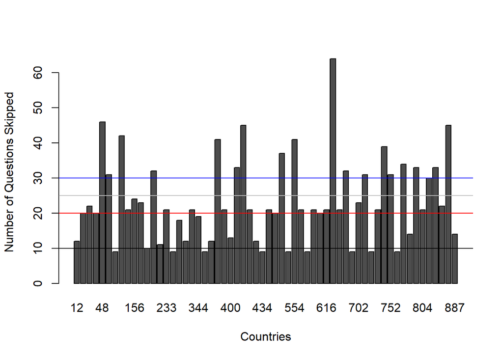

```r
barplot(t(AdminNAQuestionCount), xlab = "Countries", ylab = "Number of Questions Skipped")
abline(h=10)
abline(h=20, col="red")
abline(h=25, col="grey")
abline(h=30, col="blue")
```

Let’s also look at how many countries have more than 75% of AdminNA of all the variables.

```r
AdminNAQuestionCount75<- c()
for(i in 1:60){
 count = sum(Admin_DF_All[i,] >= 75)
 AdminNAQuestionCount75 <- rbind(AdminNAQuestionCount75, count)
 }
rownames(AdminNAQuestionCount75) <- rownames(Admin_DF_All)
sort(AdminNAQuestionCount75, decreasing = TRUE)
```

```
##  [1] 64 46 46 45 45 44 43 42 42 39 38 37 37 37 36 36 35 35 31 29 27 27 27
## [24] 26 26 26 26 26 26 26 26 26 25 25 25 25 25 25 24 23 23 23 19 19 18 18
## [47] 17 17 16 15 15 14 14 14 14 14 14 13 13  9
```

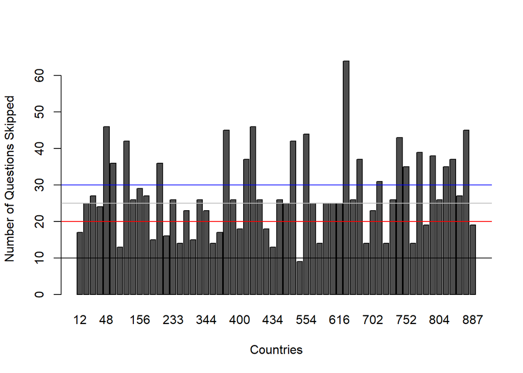

```r
barplot(t(AdminNAQuestionCount75), xlab = "Countries", ylab = "Number of Questions Skipped")
abline(h=10)
abline(h=20, col="red")
abline(h=25, col="grey")
abline(h=30, col="blue")
```

## Questions Analysis for AdminNA

We also want to elimnate questions with large amounts of administrative missing. We can understand the amount missing by counting the number of cells in each column which are greater than a certain percentage. We will look at 50, 75, 90, and 100.

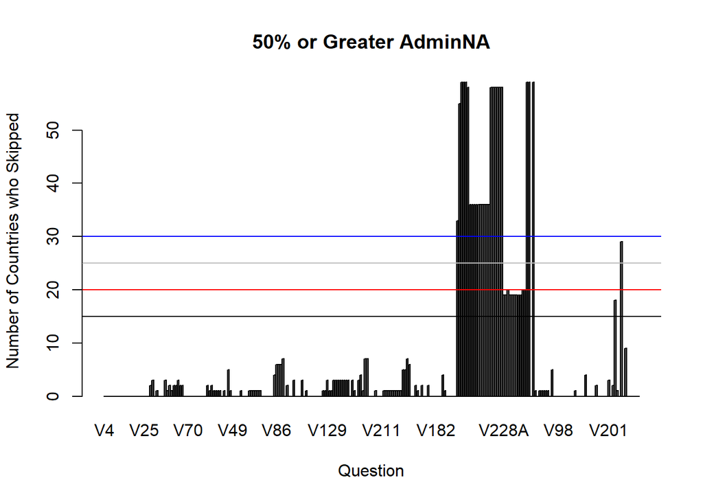

```r
QuestionCount50 = c()
count=0 #reset count

for(i in 1:255){
 count = sum(Admin_DF_All[,i] >= 50)
 QuestionCount50 <- rbind(QuestionCount50, count)
}
rownames(QuestionCount50)<-colnames(Admin_DF_All) #label with question names

barplot(t(QuestionCount50), xlab = "Question", ylab = "Number of Countries who Skipped", main = "50% or Greater AdminNA")
abline(h=15)
abline(h=20, col="red")
abline(h=25, col="grey")
abline(h=30, col="blue")
```

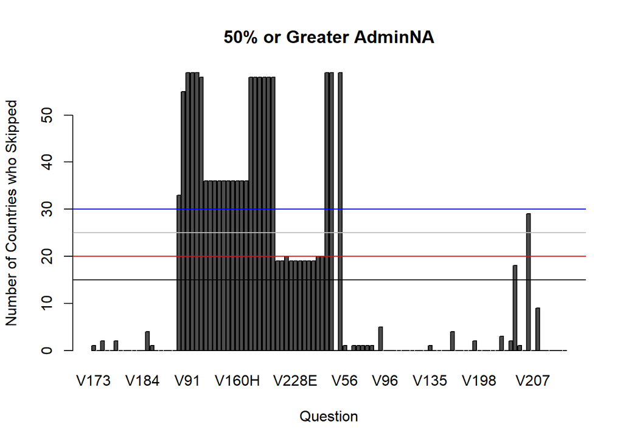

```r
barplot(t(QuestionCount50[c(150:255),1]), xlab = "Question", ylab = "Number of Countries who Skipped",
        main = "50% or Greater AdminNA", names.arg = rownames(QuestionCount50[c(150:255),]))
abline(h=15)
abline(h=20, col="red")
abline(h=25, col="grey")
abline(h=30, col="blue")
```

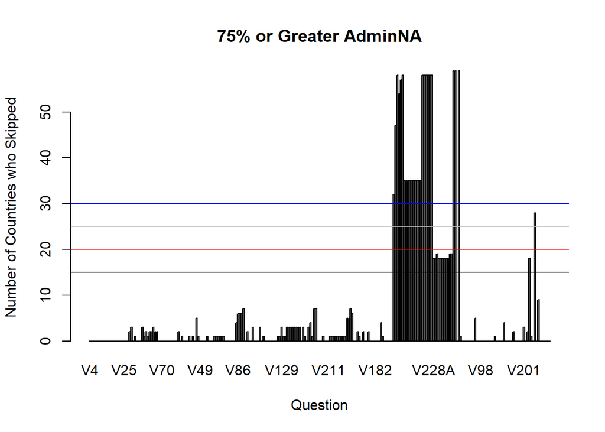

```r
QuestionCount75 = c()
count=0 #reset count

for(i in 1:255){
 count = sum(Admin_DF_All[,i] >= 75)
 QuestionCount75 <- rbind(QuestionCount75, count)
}
rownames(QuestionCount75)<-colnames(Admin_DF_All) #label with question names

barplot(t(QuestionCount75), xlab = "Question", ylab = "Number of Countries who Skipped", main = "75% or Greater AdminNA")
abline(h=15)
abline(h=20, col="red")
abline(h=25, col="grey")
abline(h=30, col="blue")
```

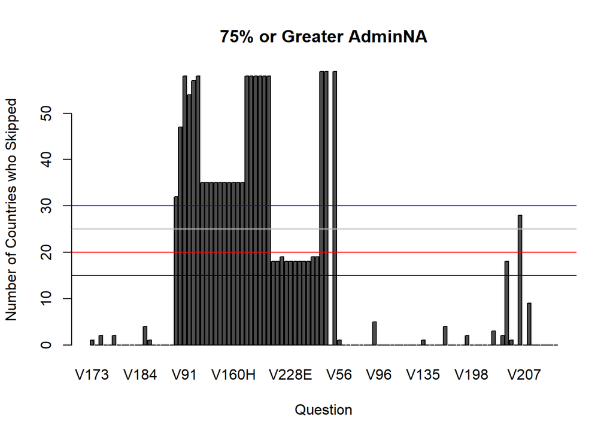

```r
barplot(t(QuestionCount75[c(150:255),1]), xlab = "Question", ylab = "Number of Countries who Skipped",
        main = "75% or Greater AdminNA", names.arg = rownames(QuestionCount75[c(150:255),]))
abline(h=15)
abline(h=20, col="red")
abline(h=25, col="grey")
abline(h=30, col="blue")
```

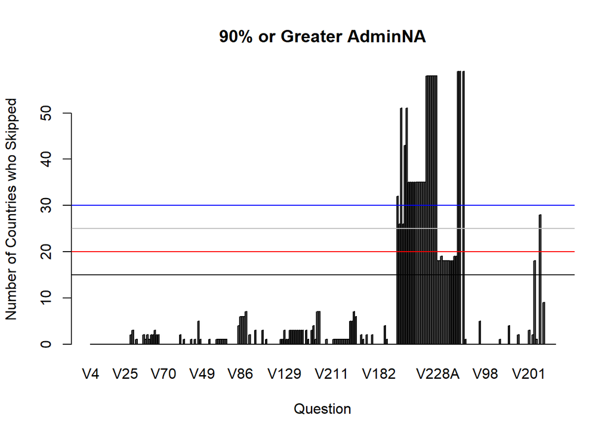

```r
QuestionCount90 = c()
count=0 #reset count

for(i in 1:255){
 count = sum(Admin_DF_All[,i] >= 90)
 QuestionCount90 <- rbind(QuestionCount90, count)
}
rownames(QuestionCount90)<-colnames(Admin_DF_All) #label with question names

barplot(t(QuestionCount90), xlab = "Question", ylab = "Number of Countries who Skipped", main = "90% or Greater AdminNA")
abline(h=15)
abline(h=20, col="red")
abline(h=25, col="grey")
abline(h=30, col="blue")
```

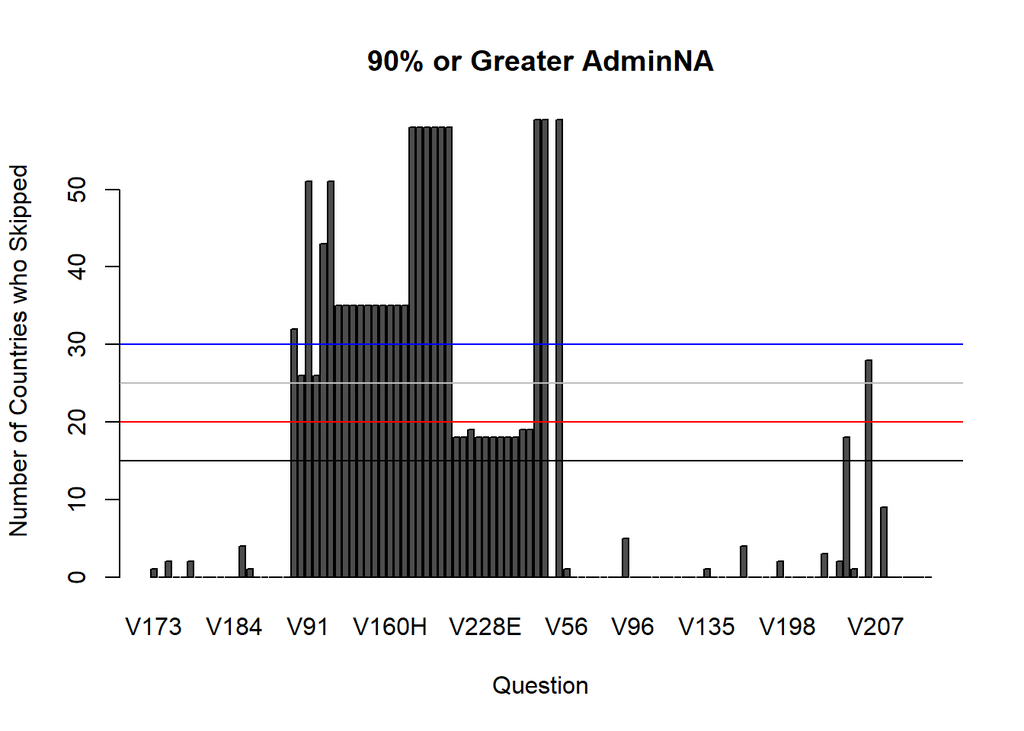

```r
barplot(t(QuestionCount90[c(150:255),1]), xlab = "Question", ylab = "Number of Countries who Skipped",
        main = "90% or Greater AdminNA", names.arg = rownames(QuestionCount90[c(150:255),]))
abline(h=15)
abline(h=20, col="red")
abline(h=25, col="grey")
abline(h=30, col="blue")
```

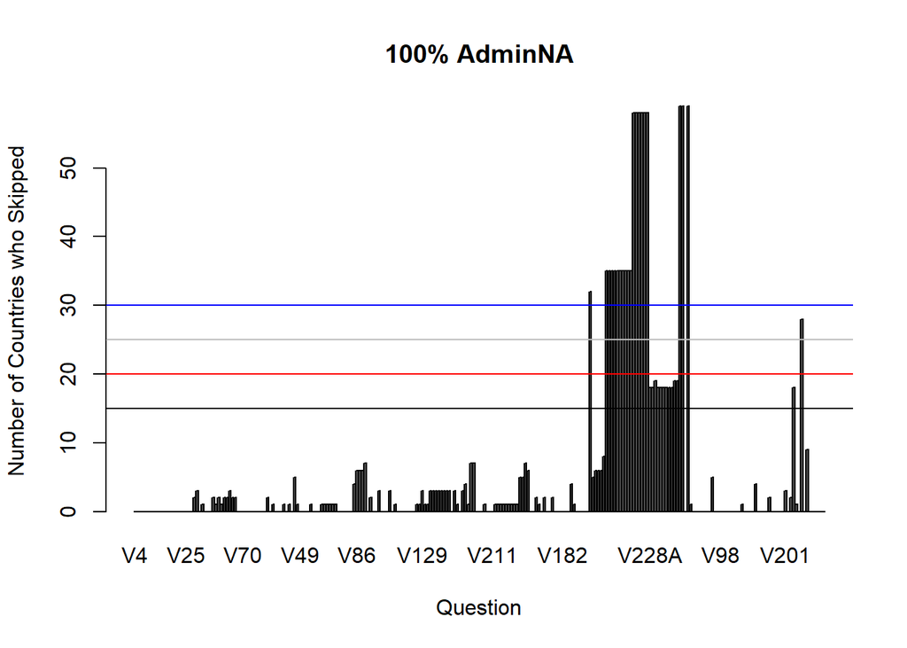

```r
QuestionCount100 = c()
count=0 #reset count

for(i in 1:255){
 count = sum(Admin_DF_All[,i] == 100)
 QuestionCount100 <- rbind(QuestionCount100, count)
}
rownames(QuestionCount100)<-colnames(Admin_DF_All) #label with question names

barplot(t(QuestionCount100), xlab = "Question", ylab = "Number of Countries who Skipped", main = "100% AdminNA")
abline(h=15)
abline(h=20, col="red")
abline(h=25, col="grey")
abline(h=30, col="blue")
```

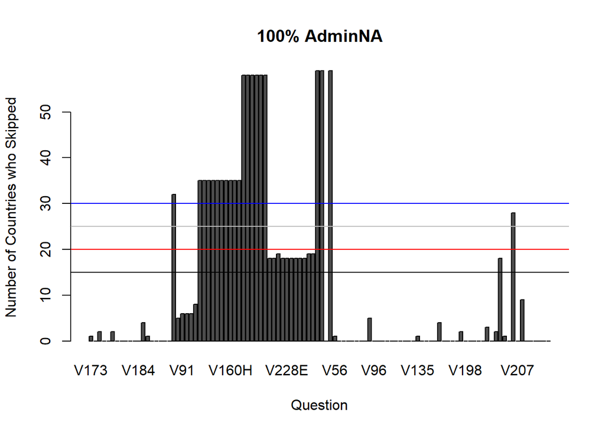

```r
barplot(t(QuestionCount100[c(150:255),1]), xlab = "Question", ylab = "Number of Countries who Skipped",
        main = "100% AdminNA", names.arg = rownames(QuestionCount100[c(150:255),]))
abline(h=15)
abline(h=20, col="red")
abline(h=25, col="grey")
abline(h=30, col="blue")
```

## Question Analysis for AdminNA (-6) Comparison

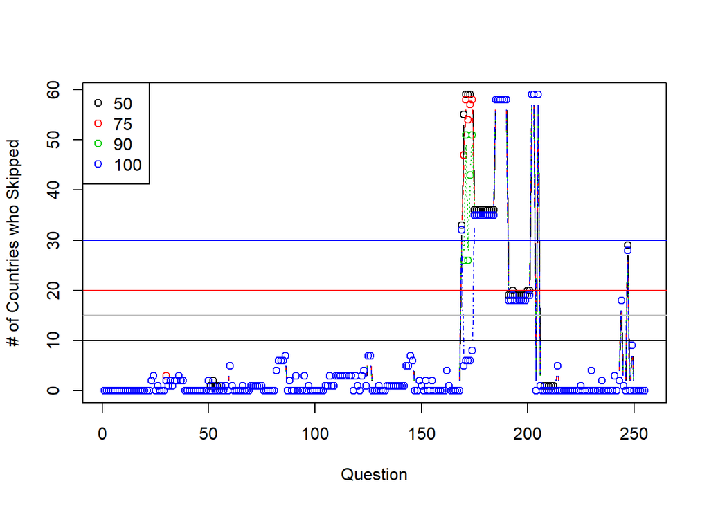

```r
Comparison_Questions_AdminNA <- cbind(QuestionCount50,QuestionCount75,QuestionCount90,QuestionCount100)

matplot(Comparison_Questions_AdminNA[c(1:255),c(1:4)], type = c("b"), pch=1, col=1:4, xlab = "Question", ylab = "# of Countries who Skipped")
legend("topleft", legend = c("50", "75", "90", "100"), col=1:4, pch=1)
abline(h=10)
abline(h=20, col="red")
abline(h=15, col="grey")
abline(h=30, col="blue")
```

```r
pdf("Comparison_Sensitivity.pdf")
matplot(Comparison_Questions_AdminNA[c(150:255),c(1:4)], type = c("b"), pch=1, col=1:4, xlab = "Question", ylab = "# of Countries who Skipped")
legend("topleft", legend = c("50", "75", "90", "100"), col=1:4, pch=1)
abline(h=10)
abline(h=20, col="red")
abline(h=15, col="grey")
abline(h=30, col="blue")
dev.off()
```

From the comparison, it seems that there is only small amounts of variation between 50% missing to 100% missing; therefore, we will remove all questions which have more than 15 countries missing at 50% or greater. In order to do this. We must create a list with those variables.

```r
#Remove the rows that are greater than 15 in from the 50% analysis.
QuestionstoRemove <- row.names(as.data.frame(which(QuestionCount50[,1] >= 15)))
Reduced_Questions <- subset(t(QuestionCount50), select = -c(which(QuestionCount50[,1] >= 15)))

Reduced_Admin_DF_All<- subset(Admin_DF_All, select = - c(V74B, V90,V91,V92,V93,V94,
                                                      V160A,V160B,V160C,V160D,V160E,V160F,V160G,V160H,V160I,V160J,
                                                      V217_ESMA,V218_ESMA,V224_ESMA,V220_ESMA,V221_ESMA,V222_ESMA,
                                                      V228A,V228B,V228C,V228D,V228E,V228F,V228G,V228H,V228I,V228J,V228K,
                                                      V243_AU,V244_AU,V56_NZ,V203A,V207A))

QuestionstoRemove
```

```
##  [1] "V74B"      "V90"       "V91"       "V92"       "V93"
##  [6] "V94"       "V160A"     "V160B"     "V160C"     "V160D"
## [11] "V160E"     "V160F"     "V160G"     "V160H"     "V160I"
## [16] "V160J"     "V217_ESMA" "V218_ESMA" "V224_ESMA" "V220_ESMA"
## [21] "V221_ESMA" "V222_ESMA" "V228A"     "V228B"     "V228C"
## [26] "V228D"     "V228E"     "V228F"     "V228G"     "V228H"
## [31] "V228I"     "V228J"     "V228K"     "V243_AU"   "V244_AU"
## [36] "V56_NZ"    "V203A"     "V207A"
```

```r
#There are 38 questions that we are removing
```

## Country Analysis for AdminNA

We will now repeat the analysis of the countries which skipped questions to see if there are a group of countries that omitted more than the rest.

```r
ReducedAdminNAQuestionCount <- c()
for(i in 1:60){
 count = sum(Reduced_Admin_DF_All[i,] == 100)
 ReducedAdminNAQuestionCount <- rbind(ReducedAdminNAQuestionCount, count)
 }
rownames(ReducedAdminNAQuestionCount) <- rownames(Reduced_Admin_DF_All)
sort(ReducedAdminNAQuestionCount, decreasing = TRUE)
```

```
##  [1] 31 26 20 20 13 11 11 10  9  8  8  8  5  4  4  4  2  2  2  2  2  2  1
## [24]  1  1  1  1  0  0  0  0  0  0  0  0  0  0  0  0  0  0  0  0  0  0  0
## [47]  0  0  0  0  0  0  0  0  0  0  0  0  0  0
```

```r
pdf("ReducedAdminNAQuestionCount.pdf")
barplot(t(ReducedAdminNAQuestionCount), xlab = "Countries", ylab = "Number of Questions Skipped")
abline(h=5)
abline(h=10, col="red")
abline(h=15, col="grey")
abline(h=20, col="blue")
dev.off()
```

```r
#To see which questions they skipped
Removed_Countries_AdminNA <- Reduced_Admin_DF_All[rownames(Reduced_Admin_DF_All) %in% c(414, 634,48,818), ]

pdf("Questionstheyskipped.pdf")
matplot(t(Removed_Countries_AdminNA), type = c("p"), pch=1, col=1:4, xlab = "Question", ylab = "% of People not asked Question")
legend("topleft", legend = row.names(Removed_Countries_AdminNA), col=1:4, pch=1)
dev.off()
```

# Sensitivity Analysis for Missing (-2)

There are certain countries with high values of AdminNA values in the data frame. We have the choice of either removing variables or countries.

```r
Missing_DF <- c()
for(df in Cat_Precentage_DFs_list){
  Missing_DF_add <- df[,11]
  Missing_DF <- cbind(Missing_DF, Missing_DF_add)
}
Cat_Question_Column_Names_Missing <- names(Cat_Precentage_DFs_list)
colnames(Missing_DF) <- Cat_Question_Column_Names_Missing
rownames(Missing_DF) <- country.codes

Missing_DF_All<- as.data.frame(cbind(Missing_DF, Missing_DF_Ordinal))
#colSums(is.na(Missing_DF_All)) #double checking that there are no NAs
```

## Question Analysis for Missing (-2)

Let’s also look at the missing responses. We can understand the amount missing by counting the number of cells in each column which are greater than a certain percentage. We will look at 50, 75, 90, and 100% and then compare them all.

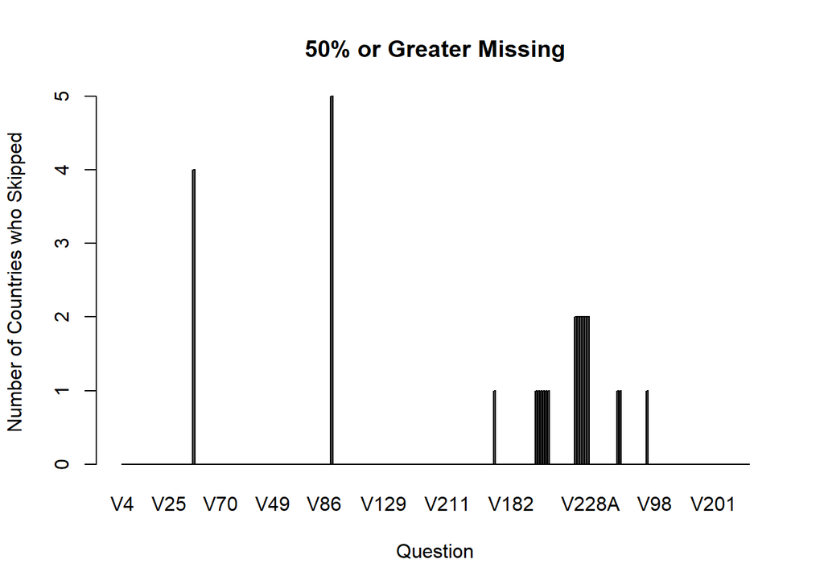

```r
QuestionCount50 = c()
count=0 #reset count

for(i in 1:255){
 count = sum(Missing_DF_All[,i] >= 50)
 QuestionCount50 <- rbind(QuestionCount50, count)
}
rownames(QuestionCount50)<-colnames(Missing_DF_All) #label with question names

barplot(t(QuestionCount50), xlab = "Question", ylab = "Number of Countries who Skipped", main = "50% or Greater Missing")
abline(h=15)
abline(h=20, col="red")
abline(h=25, col="grey")
abline(h=30, col="blue")
```

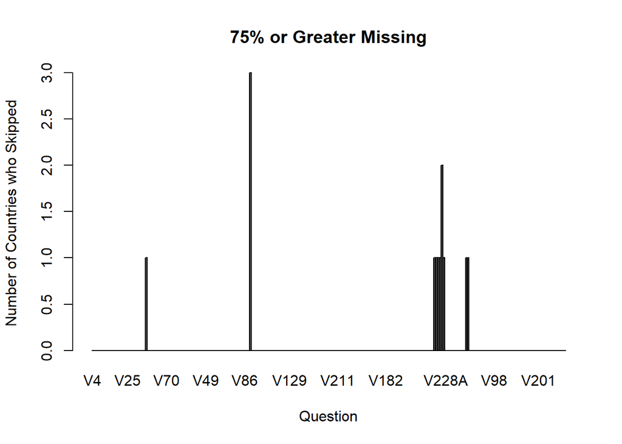

```r
QuestionCount75 = c()
count=0 #reset count

for(i in 1:255){
 count = sum(Missing_DF_All[,i] >= 75)
 QuestionCount75 <- rbind(QuestionCount75, count)
}
rownames(QuestionCount75)<-colnames(Missing_DF_All) #label with question names

barplot(t(QuestionCount75), xlab = "Question", ylab = "Number of Countries who Skipped", main = "75% or Greater Missing")
abline(h=15)
abline(h=20, col="red")
abline(h=25, col="grey")
abline(h=30, col="blue")
```

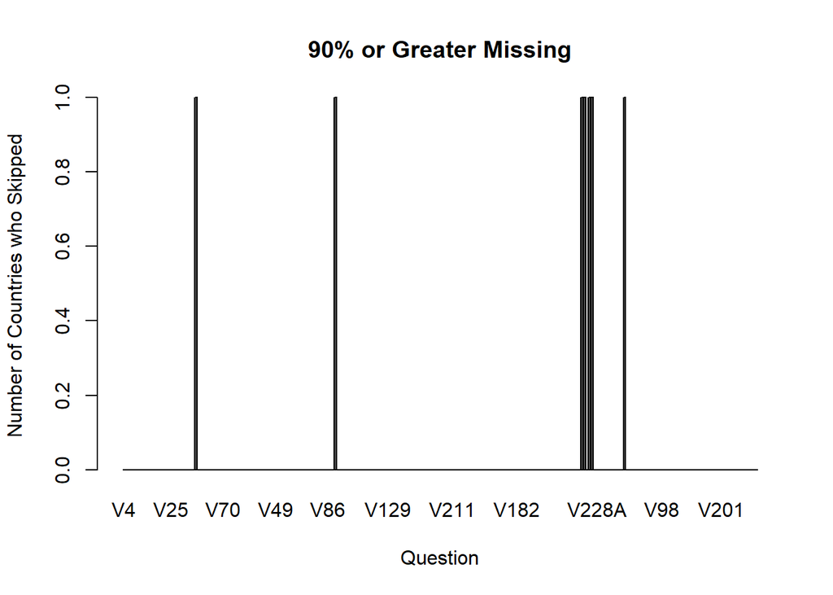

```r
QuestionCount90 = c()
count=0 #reset count

for(i in 1:255){
 count = sum(Missing_DF_All[,i] >= 90)
 QuestionCount90 <- rbind(QuestionCount90, count)
}
rownames(QuestionCount90)<-colnames(Missing_DF_All) #label with question names

barplot(t(QuestionCount90), xlab = "Question", ylab = "Number of Countries who Skipped", main = "90% or Greater Missing")
abline(h=15)
abline(h=20, col="red")
abline(h=25, col="grey")
abline(h=30, col="blue")
```

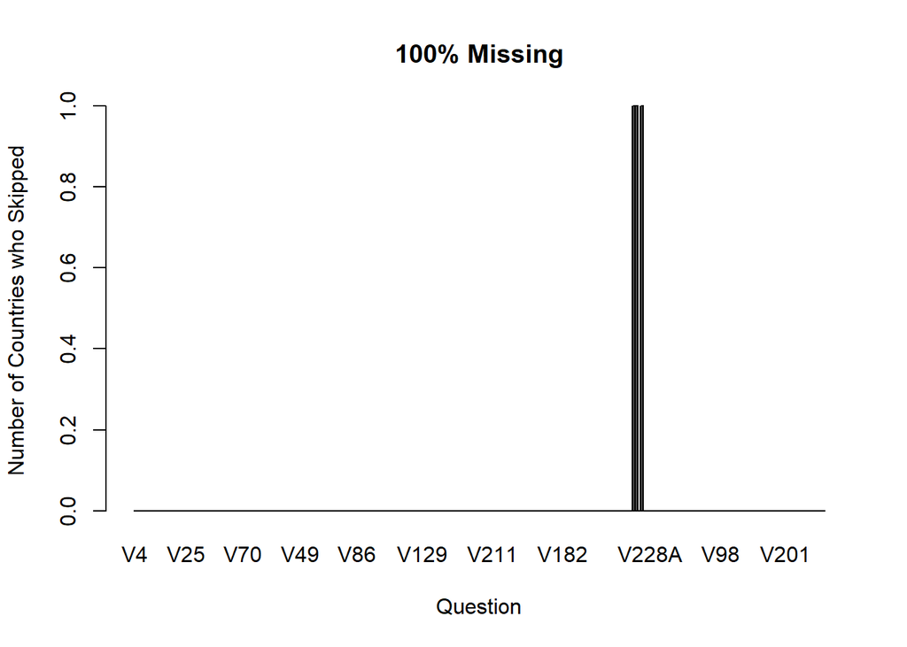

```r
QuestionCount100 = c()
count=0 #reset count

for(i in 1:255){
 count = sum(Missing_DF_All[,i] == 100)
 QuestionCount100 <- rbind(QuestionCount100, count)
}
rownames(QuestionCount100)<-colnames(Missing_DF_All) #label with question names

barplot(t(QuestionCount100), xlab = "Question", ylab = "Number of Countries who Skipped", main = "100% Missing")
abline(h=15)
abline(h=20, col="red")
abline(h=25, col="grey")
abline(h=30, col="blue")
```

### Question Analysis for Missing (-2) Comparison

```r
Comparison_Questions_Missing <- cbind(QuestionCount50,QuestionCount75,QuestionCount90,QuestionCount100)
pdf("Comparison_Sensitivity - Missing(-2).pdf")
matplot(Comparison_Questions_Missing[c(1:255),c(1:4)], type = c("b"), pch=1, col=1:4, xlab = "Question", ylab = "# of Countries who Skipped")
legend("topleft", legend = c("50", "75", "90", "100"), col=1:4, pch=1)
abline(h=10)
abline(h=20, col="red")
abline(h=15, col="grey")
abline(h=30, col="blue")
dev.off()
```

```r
#Remove the rows that are greater than 15 in from the 50% analysis.
QuestionstoRemove <- row.names(as.data.frame(which(QuestionCount50[,1] >= 15)))
Reduced_Questions <- subset(t(QuestionCount50), select = -c(which(QuestionCount50[,1] >= 15)))

QuestionstoRemove
```

```
## character(0)
```